# MultiNicheNet analysis: anti-PD1 Breast cancer multifactorial comparison

### 2.4.2 Interpret the analysis

*Summarizing ChordDiagram circos plots*

We will look here at the top 50 predictions across all contrasts, senders, and receivers of interest.

```r
prioritized_tbl_oi_all = get_top_n_lr_pairs(
  multinichenet_output$prioritization_tables,
  top_n = 50,
  rank_per_group = FALSE
  )
```

```r
prioritized_tbl_oi =
  multinichenet_output$prioritization_tables$group_prioritization_tbl %>%
  filter(id %in% prioritized_tbl_oi_all$id) %>%
  distinct(id, sender, receiver, ligand, receptor, group) %>%
  left_join(prioritized_tbl_oi_all)
prioritized_tbl_oi$prioritization_score[is.na(prioritized_tbl_oi$prioritization_score)] = 0

senders_receivers = union(prioritized_tbl_oi$sender %>% unique(), prioritized_tbl_oi$receiver %>% unique()) %>% sort()

colors_sender = RColorBrewer::brewer.pal(n = length(senders_receivers), name = 'Spectral') %>% magrittr::set_names(senders_receivers)
colors_receiver = RColorBrewer::brewer.pal(n = length(senders_receivers), name = 'Spectral') %>% magrittr::set_names(senders_receivers)

circos_list = make_circos_group_comparison(prioritized_tbl_oi, colors_sender, colors_receiver)
```

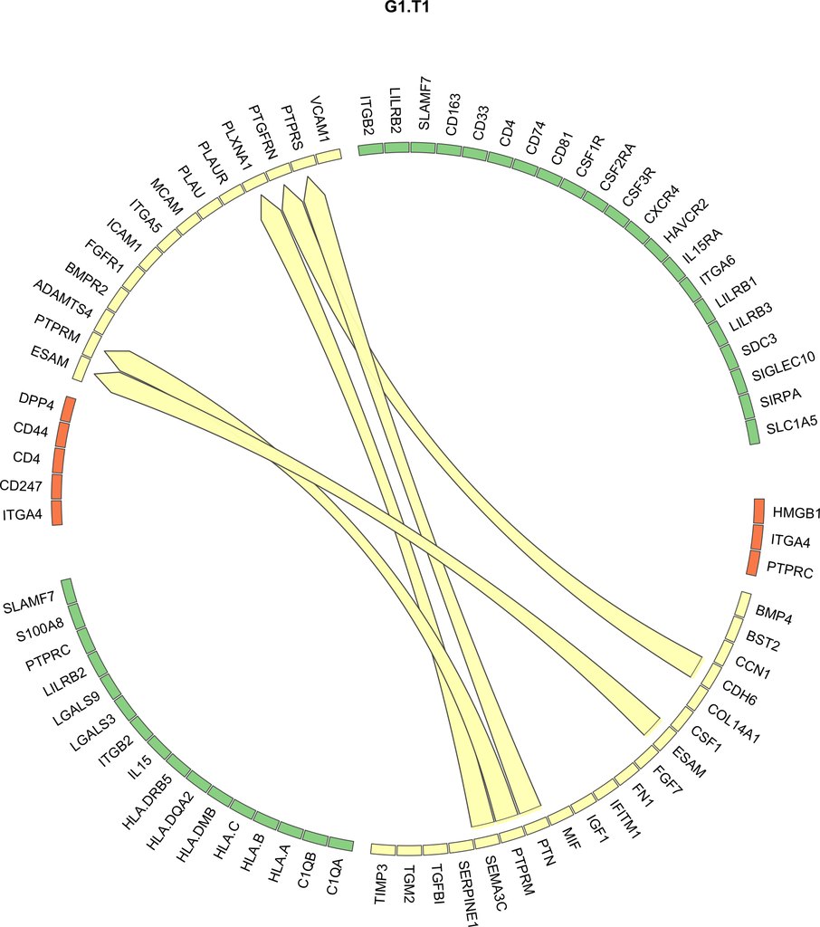

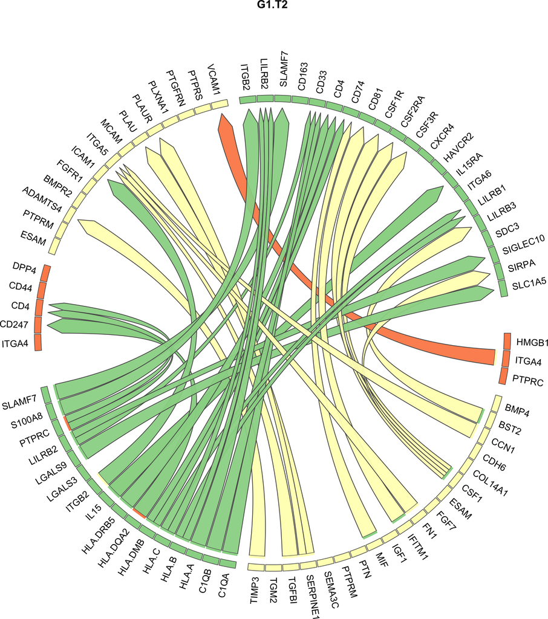

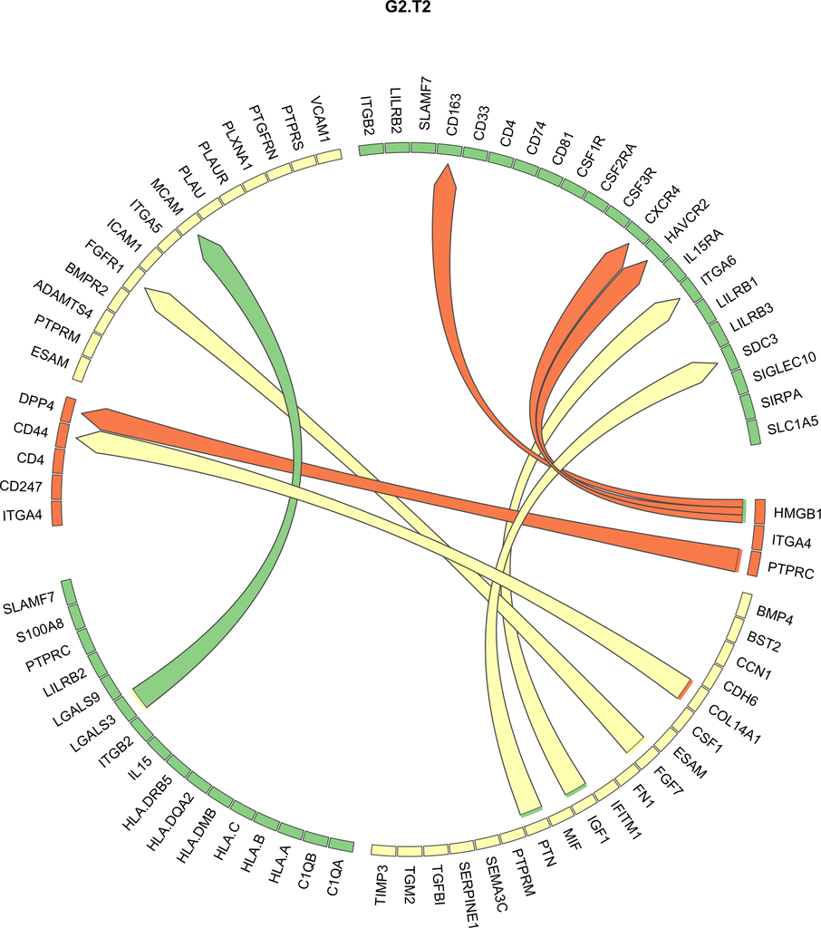

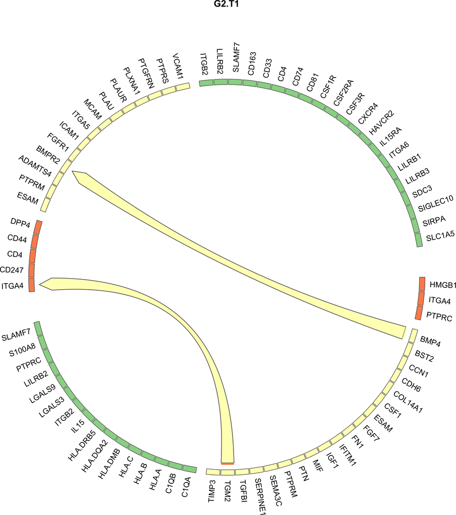

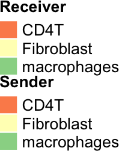

In general, we see most specific interactions are the ones that increase in the E group (= patients with T cell clonotype expansion after aPD1 therapy)

*Interpretable bubble plots*

We will now check the top interactions specific for the OnE group - so these are the interactions that increase during anti-PD1 therapy and more strongly in the E than NE group.

```r
group_oi = "G1.T2"
```

```r
prioritized_tbl_oi_50 = get_top_n_lr_pairs(
  multinichenet_output$prioritization_tables,
  top_n = 50, rank_per_group = FALSE) %>% filter(group == group_oi)
```

```r
prioritized_tbl_oi_50_omnipath = prioritized_tbl_oi_50 %>%
  inner_join(lr_network_all)
```

Now we add this to the bubble plot visualization:

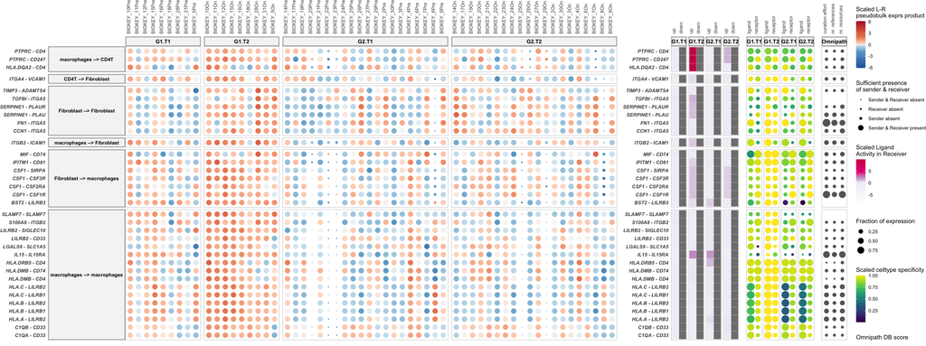

```r
plot_oi = make_sample_lr_prod_activity_plots_Omnipath(
  multinichenet_output$prioritization_tables,
  prioritized_tbl_oi_50_omnipath)
plot_oi
```

Now let’s check the top interactions specific for the PreE group - so these are the interactions that decrease during anti-PD1 therapy, and more strongly in group1 than group2.

```r
group_oi = "G1.T1"
```

```r
prioritized_tbl_oi_50 = get_top_n_lr_pairs(
  multinichenet_output$prioritization_tables,
  top_n = 50, rank_per_group = FALSE) %>% filter(group == group_oi)
```

```r
prioritized_tbl_oi_50_omnipath = prioritized_tbl_oi_50 %>%
  inner_join(lr_network_all)
```

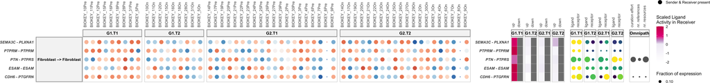

```r
plot_oi = make_sample_lr_prod_activity_plots_Omnipath(
  multinichenet_output$prioritization_tables,
  prioritized_tbl_oi_50_omnipath)
plot_oi
```

These are just a few interactions because they should be part of top50. Let’s now look at some more interactions: top25 within PreE.

```r
prioritized_tbl_oi_50 = get_top_n_lr_pairs(
  multinichenet_output$prioritization_tables,
  top_n = 25, groups = group_oi)
```

```r
prioritized_tbl_oi_50_omnipath = prioritized_tbl_oi_50 %>%
  inner_join(lr_network_all)
```

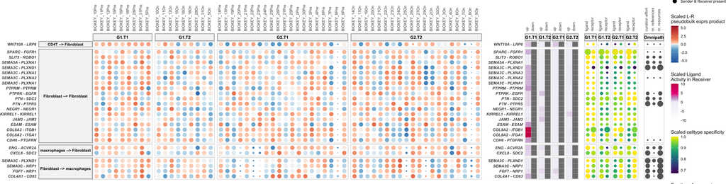

```r
plot_oi = make_sample_lr_prod_activity_plots_Omnipath(
  multinichenet_output$prioritization_tables,
  prioritized_tbl_oi_50_omnipath)
plot_oi
```

We recommend generating these plots as well for the other conditions, but we will not do this here to reduce the length of the vignette.

### 2.4.3 Intercellular regulatory network inference and visualization

One of the unique benefits of MultiNicheNet is the prediction of ligand activities and target genes downstream of ligand-receptor pairs. This may offer additional unique insights into the data at hand. We will showcase this here by inferring an intercellular regulatory network. Interestingly, some target genes can be ligands or receptors themselves. This illustrates that cells can send signals to other cells, who as a response to these signals produce signals themselves to feedback to the original sender cells, or who will effect other cell types. With MultiNicheNet, we can generate this ‘systems’ view of these intercellular feedback and cascade processes than can be occuring between the different cell populations involved. In this intercellular regulatory network, we will draw links between ligands of sender cell types their ligand/receptor-annotated target genes in receiver cell types. So links are ligand-target links (= gene regulatory links) and not ligand-receptor protein-protein interactions!

Because we typically predict many target genes for each ligand, we may get a crowded ligand-target network in the end. To prune this network, we can filter target genes based on correlation in expression across samples with their upstream ligand-receptor pairs.

So, before inferring the intercellular regulatory network, we will calculate these LR-target correlations:

```r
lr_target_prior_cor = lr_target_prior_cor_inference(
  receivers_oi = multinichenet_output$prioritization_tables$group_prioritization_tbl$receiver %>% unique(),
  abundance_expression_info = abundance_expression_info,
  celltype_de = celltype_de_LR,
  grouping_tbl = multinichenet_output$grouping_tbl,
  prioritization_tables = multinichenet_output$prioritization_tables,
  ligand_target_matrix = ligand_target_matrix,
  logFC_threshold = logFC_threshold,
  p_val_threshold = p_val_threshold,
  p_val_adj = p_val_adj
  )
```

In the plots before, we demonstrated that some DE genes have both expression correlation and prior knowledge support to be downstream of ligand-receptor pairs. We will infer this intercellular regulatory network here for the top250 interactions overall.

```r
prioritized_tbl_oi = get_top_n_lr_pairs(
  multinichenet_output$prioritization_tables,
  250,
  rank_per_group = FALSE)

lr_target_prior_cor_filtered =
  multinichenet_output$prioritization_tables$group_prioritization_tbl$group %>% unique() %>%
  lapply(function(group_oi){
    lr_target_prior_cor_filtered = lr_target_prior_cor %>%
      inner_join(
        multinichenet_output$ligand_activities_targets_DEgenes$ligand_activities %>%
          distinct(ligand, target, direction_regulation, contrast)
        ) %>%
      inner_join(contrast_tbl) %>% filter(group == group_oi)

    lr_target_prior_cor_filtered_up = lr_target_prior_cor_filtered %>%
      filter(direction_regulation == "up") %>%
      filter( (rank_of_target < top_n_target) & (pearson > 0.2 | spearman > 0.2))

    lr_target_prior_cor_filtered_down = lr_target_prior_cor_filtered %>%
      filter(direction_regulation == "down") %>%
      filter( (rank_of_target < top_n_target) & (pearson < -0.2 | spearman < -0.2))
    lr_target_prior_cor_filtered = bind_rows(
      lr_target_prior_cor_filtered_up,
      lr_target_prior_cor_filtered_down
      )
}) %>% bind_rows()

lr_target_df = lr_target_prior_cor_filtered %>%
  distinct(group, sender, receiver, ligand, receptor, id, target, direction_regulation)
```

```r
network = infer_intercellular_regulatory_network(lr_target_df, prioritized_tbl_oi)
network$links %>% head()
## # A tibble: 6 × 6
##   sender_ligand     receiver_target     direction_regulation group type          weight
##   <chr>             <chr>               <fct>                <chr> <chr>          <dbl>
## 1 Fibroblast_TIMP1  Fibroblast_SERPINE1 up                   G1.T2 Ligand-Target      1
## 2 Fibroblast_TIMP1  Fibroblast_TIMP1    up                   G1.T2 Ligand-Target      1
## 3 Fibroblast_FN1    Fibroblast_SERPINE1 up                   G1.T2 Ligand-Target      1
## 4 macrophages_B2M   Fibroblast_TIMP1    up                   G1.T2 Ligand-Target      1
## 5 macrophages_ITGB2 Fibroblast_SERPINE1 up                   G1.T2 Ligand-Target      1
## 6 macrophages_ITGB2 Fibroblast_TIMP1    up                   G1.T2 Ligand-Target      1
network$nodes %>% head()
## # A tibble: 6 × 4
##   node              celltype    gene  type_gene
##   <chr>             <chr>       <chr> <chr>
## 1 macrophages_PTPRC macrophages PTPRC ligand/receptor
## 2 Fibroblast_ICAM1  Fibroblast  ICAM1 ligand/receptor
## 3 CD4T_CD28         CD4T        CD28  ligand/receptor
## 4 Fibroblast_TIMP1  Fibroblast  TIMP1 ligand
## 5 Fibroblast_FN1    Fibroblast  FN1   ligand
## 6 macrophages_B2M   macrophages B2M   ligand
```

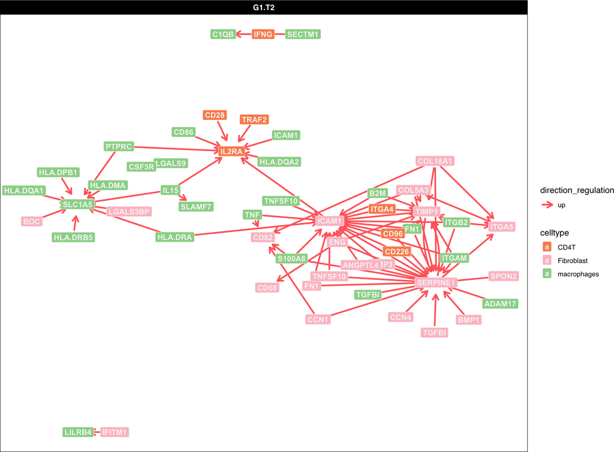

```r
colors_sender["Fibroblast"] = "pink" # the  original yellow background with white font is not very readable
network_graph = visualize_network(network, colors_sender)
network_graph$plot
```

Interestingly, we are only left with interactions that increase after therapy in the E group. This means that we don’t find many intercellular regulatory connections for the other groups. In most cases, you will get this type of network for all conditions in your data.

Note: we can also use this network to further prioritize differential CCC interactions. Here we will assume that the most important LR interactions are the ones that are involved in this intercellular regulatory network. We can get these interactions as follows:

```r
network$prioritized_lr_interactions
## # A tibble: 61 × 5
##    group sender      receiver   ligand   receptor
##    <chr> <chr>       <chr>      <chr>    <chr>
##  1 G1.T2 Fibroblast  Fibroblast TIMP1    CD63
##  2 G1.T2 Fibroblast  Fibroblast FN1      ITGA5
##  3 G1.T2 macrophages Fibroblast B2M      TAP1
##  4 G1.T2 macrophages Fibroblast ITGB2    THY1
##  5 G1.T2 Fibroblast  Fibroblast FN1      NT5E
##  6 G1.T2 Fibroblast  Fibroblast TIMP3    ADAMTS4
##  7 G1.T2 Fibroblast  Fibroblast SERPINE1 PLAU
##  8 G1.T2 Fibroblast  Fibroblast SERPINE1 PLAUR
##  9 G1.T2 Fibroblast  Fibroblast CCN1     ITGA5
## 10 G1.T2 macrophages Fibroblast FN1      ITGA5
## # ℹ 51 more rows
```

```r
prioritized_tbl_oi_network = prioritized_tbl_oi %>% inner_join(
  network$prioritized_lr_interactions)
prioritized_tbl_oi_network
## # A tibble: 61 × 8
##    group sender      receiver    ligand   receptor id                                    prioritization_score prioritization_rank
##    <chr> <chr>       <chr>       <chr>    <chr>    <chr>                                                <dbl>               <dbl>
##  1 G1.T2 Fibroblast  Fibroblast  SERPINE1 PLAU     SERPINE1_PLAU_Fibroblast_Fibroblast                  0.926                   2
##  2 G1.T2 macrophages macrophages IL15     IL15RA   IL15_IL15RA_macrophages_macrophages                  0.925                   3
##  3 G1.T2 macrophages CD4T        PTPRC    CD247    PTPRC_CD247_macrophages_CD4T                         0.919                   4
##  4 G1.T2 Fibroblast  Fibroblast  TGFBI    ITGA5    TGFBI_ITGA5_Fibroblast_Fibroblast                    0.911                   7
##  5 G1.T2 Fibroblast  Fibroblast  TIMP3    ADAMTS4  TIMP3_ADAMTS4_Fibroblast_Fibroblast                  0.895                  13
##  6 G1.T2 CD4T        Fibroblast  ITGA4    VCAM1    ITGA4_VCAM1_CD4T_Fibroblast                          0.894                  14
##  7 G1.T2 Fibroblast  Fibroblast  SERPINE1 PLAUR    SERPINE1_PLAUR_Fibroblast_Fibroblast                 0.886                  21
##  8 G1.T2 macrophages Fibroblast  ITGB2    ICAM1    ITGB2_ICAM1_macrophages_Fibroblast                   0.885                  22
##  9 G1.T2 macrophages macrophages HLA.DRB5 CD4      HLA.DRB5_CD4_macrophages_macrophages                 0.883                  24
## 10 G1.T2 macrophages macrophages LGALS9   SLC1A5   LGALS9_SLC1A5_macrophages_macrophages                0.877                  29
## # ℹ 51 more rows
```

Visualize now the expression and activity of these interactions for the OnE group

```r
group_oi = "G1.T2"
```

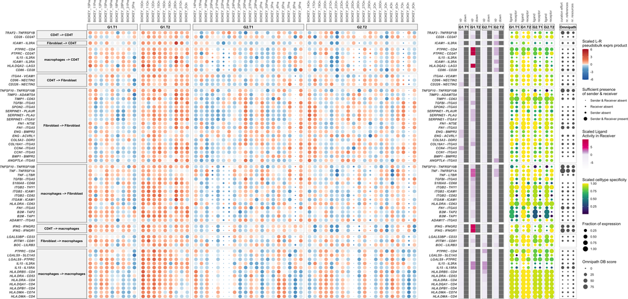

```r
prioritized_tbl_oi_M = prioritized_tbl_oi_network %>% filter(group == group_oi)

plot_oi = make_sample_lr_prod_activity_plots_Omnipath(
  multinichenet_output$prioritization_tables,
  prioritized_tbl_oi_M %>% inner_join(lr_network_all)
  )
plot_oi
```

### 2.4.4 Plots of cell-cell communication changes

All the above visualizations were general and not specific to the multifactorial design and complex contrast of this data and analysis. In the final part of this vignette, we will demonstrate some visualizations that better showcase differences in therapy-induced cell-cell communication changes. Because it is very hard to do this for the final MultiNicheNet prioritization score including both expression and activity, we will only visualize ligand-receptor expression in the following plots. But realise that the interactions we will show are prioritized by MultiNicheNet not only based on differential expression, but thus also cell-type specificity and ligand activity.

As example, we will focus on the top 10 interactions with stronger On-Pre differences in group1 versus group2.

```r
prioritized_tbl_oi = get_top_n_lr_pairs(multinichenet_output$prioritization_tables, 10, rank_per_group = TRUE, groups_oi = "G1.T2")
```

A first visualization will not require that the timepoint 1 and timepoint 2 samples were gathered from the same subjects. The other visualization will assume this, and can only be generated in those scenarios.

*Boxplots of LR pseudobulk expression product*

In the following blocks of code, we will first create and reformat a data frame so that we know for each sample the time point (timepoint.1/Pre or timepoint.2/On) and patient group (group1/E or group2/NE), and also what the pseudobulk expression product is for a ligand-receptor pair.

```r
# create sample-level data frame for these interactions
sample_data = multinichenet_output$prioritization_tables$sample_prioritization_tbl %>% dplyr::filter(id %in% prioritized_tbl_oi$id) %>% dplyr::mutate(sender_receiver = paste(sender, receiver, sep = " --> "), lr_interaction = paste(ligand, receptor, sep = " - "))   %>%  dplyr::arrange(receiver) %>% dplyr::group_by(receiver) %>%  dplyr::arrange(sender, .by_group = TRUE)

sample_data = sample_data %>% dplyr::mutate(sender_receiver = factor(sender_receiver, levels = sample_data$sender_receiver %>% unique()))
```

```r
# define the time point and group and link it all together
grouping_tbl2 = multinichenet_output$grouping_tbl %>% dplyr::inner_join(multinichenet_output$prioritization_tables$sample_prioritization_tbl %>% dplyr::distinct(sample))
grouping_tbl2 = grouping_tbl2 %>% inner_join(tibble(group = c("G1.T1","G2.T1","G1.T2","G2.T2"), contrast = c("group1","group2","group1","group2")))

grouping_tbl2$timepoint = "timepoint2"
grouping_tbl2$timepoint[grouping_tbl2$group %in% c("G1.T1","G2.T1")] = "timepoint1"

sample_data = sample_data %>% ungroup() %>%
  inner_join(grouping_tbl2)

sample_data = sample_data %>% select(sample, group, contrast, timepoint, id, ligand_receptor_pb_prod) %>% distinct()
```

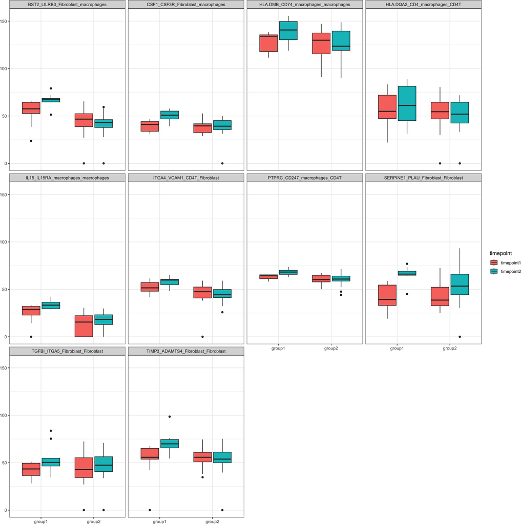

```r
p_lr_prod_change_boxplot = sample_data %>%
    ggplot(aes(x = contrast, y = ligand_receptor_pb_prod, fill = timepoint, group = group)) +
    geom_boxplot() +
    facet_wrap(id~.) +
    theme_bw() +
    xlab("") + ylab("")

p_lr_prod_change_boxplot
```

These boxplots reflect what the DE model underlying MultiNicheNet infers: namely average group differences.

However, these boxplots don’t show potential inter-sample heterogeneity. That’s why we will also create bubble and line plots in the following blocks of code. In those plots we will calculate the timepoint2 vs timepoint1 differences for each subject separately. Therefore, you can only generate those if you have this type of experimental design (same subject, multiple time points).

*Difference plots*

Prepare the appropriate data frame structure to create this plots. This will be very similar to the previous blocks of code. Exception: we will now also include information about the subject the samples were collected from + whether sender and receiver cell types were sufficiently present in each subject both before and on treatment.

First: link sample_id to subject_id:

```r
sample_subject_tbl = colData(sce) %>% as_tibble() %>% distinct(patient_id, sample_id) %>% rename(subject = patient_id, sample = sample_id)
```

Create sample-level data frame for these interactions

```r
sample_data = multinichenet_output$prioritization_tables$sample_prioritization_tbl %>% dplyr::filter(id %in% prioritized_tbl_oi$id) %>% dplyr::mutate(sender_receiver = paste(sender, receiver, sep = " --> "), lr_interaction = paste(ligand, receptor, sep = " - "))   %>%  dplyr::arrange(receiver) %>% dplyr::group_by(receiver) %>%  dplyr::arrange(sender, .by_group = TRUE)

sample_data = sample_data %>% dplyr::mutate(sender_receiver = factor(sender_receiver, levels = sample_data$sender_receiver %>% unique()))
```

Define the time point and group and link it all together

```r
grouping_tbl2 = multinichenet_output$grouping_tbl %>% dplyr::inner_join(multinichenet_output$prioritization_tables$sample_prioritization_tbl %>% dplyr::distinct(sample, sender, receiver, keep_sender, keep_receiver))
grouping_tbl2 = grouping_tbl2 %>% inner_join(tibble(group = c("G1.T1","G2.T1","G1.T2","G2.T2"), contrast = c("group1","group2","group1","group2")))

grouping_tbl2$timepoint = "timepoint2"
grouping_tbl2$timepoint[grouping_tbl2$group %in% c("G1.T1","G2.T1")] = "timepoint1"

sample_data = sample_data %>% ungroup() %>%
  inner_join(grouping_tbl2) %>%
  inner_join(sample_subject_tbl)

sample_data = sample_data %>% select(subject, sample, group, contrast, timepoint, sender_receiver, keep_sender, keep_receiver, keep_sender_receiver, ligand, receptor, lr_interaction, id, ligand_receptor_pb_prod, scaled_LR_pb_prod) %>% distinct()
```

Then we will remove samples where sender and/or receiver was missing and calculate the On-vs-Pre difference in pseudobulk expression (absolute and relative difference, named respectively `diff` and `lfc`).

```r
sample_data = sample_data %>% filter(keep_sender & keep_receiver) %>% mutate(group = factor(group, levels = c("G2.T1","G1.T1", "G2.T2","G1.T2")), timepoint = factor(timepoint, levels = c("timepoint1","timepoint2")))
sample_data = sample_data %>% inner_join(
  sample_data %>% filter(keep_receiver == 1 & keep_sender == 1) %>% ungroup() %>% select(id, subject, timepoint, ligand_receptor_pb_prod) %>% distinct() %>% tidyr::spread(timepoint, ligand_receptor_pb_prod) %>% mutate(diff = timepoint2-timepoint1, fc = timepoint2/timepoint1) %>% mutate(lfc = log(fc)) %>% arrange(-lfc)
  )
```

For the visualization, we will also order the subjects based the total difference across all shown interactions:

```r
order_subjects = sample_data %>% group_by(subject) %>% summarise(sum_diff = sum(diff, na.rm = TRUE)) %>% arrange(-sum_diff) %>% pull(subject)
order_samples = sample_data %>% group_by(subject) %>% summarise(sum_diff = sum(diff, na.rm = TRUE)) %>% inner_join(sample_data) %>% arrange(-sum_diff) %>% pull(sample) %>% unique()
```

*Difference Bubble plots*

Bubble Blot for E group

We will now visualize the On-vs-Pre absolute difference in pseudobulk ligand-receptor expression product in a bubble plot.

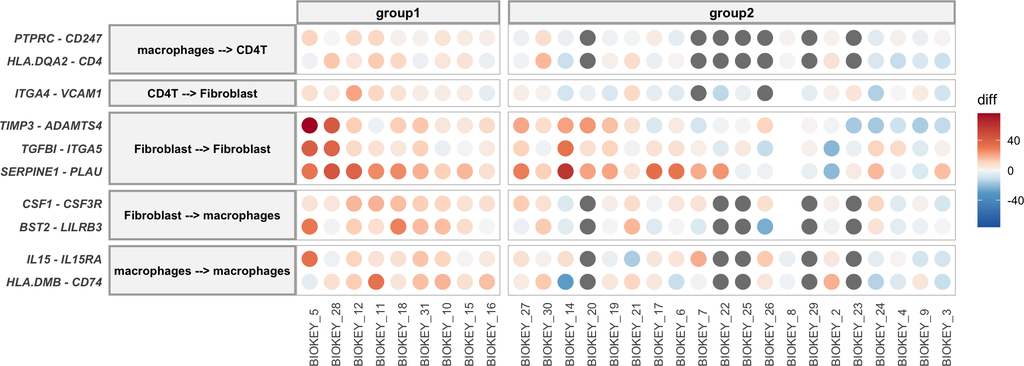

```r
max_diff = abs(sample_data$diff) %>% max(na.rm = TRUE)
custom_scale_color = scale_color_gradientn(colours = RColorBrewer::brewer.pal(n = 7,
        name = "RdBu") %>% rev(), values = c(0, 0.30, 0.425,
        0.5, 0.575, 0.70, 1), limits = c(-1 * max_diff, max_diff))

p_lr_prod_change = sample_data %>% mutate(subject = factor(subject, levels = order_subjects)) %>%
    ggplot(aes(subject, lr_interaction, color = diff)) +
    geom_point(size = 5) +
    facet_grid(sender_receiver~contrast, scales = "free", space = "free", switch = "y") +
    theme_light() +
        theme(axis.ticks = element_blank(), axis.title = element_blank(),
            axis.text.y = element_text(face = "bold.italic",
                size = 9), axis.text.x = element_text(size = 9,
                angle = 90, hjust = 0), panel.grid.major = element_blank(),
            panel.grid.minor = element_blank(), panel.spacing.x = unit(0.4,
                "lines"), panel.spacing.y = unit(0.25,
                "lines"), strip.text.x.top = element_text(size = 10,
                color = "black", face = "bold", angle = 0),
            strip.text.y.left = element_text(size = 9, color = "black",
                face = "bold", angle = 0), strip.background = element_rect(color = "darkgrey",
                fill = "whitesmoke", size = 1.5, linetype = "solid")) +
    custom_scale_color +
    xlab("") + ylab("")
p_lr_prod_change
```

All interactions increased in exrpession in almost all group1 subjects, and certainly not in all group2 subjects.

*Line plots*

Another type of plot to visualize this type of data is the line plot:

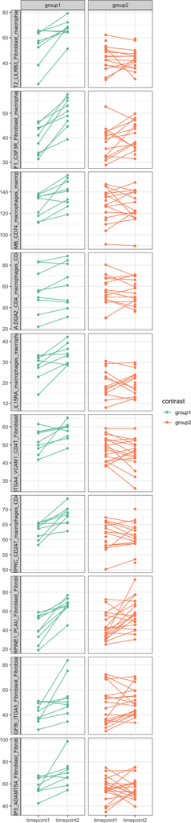

```r
line_plot = sample_data %>% filter(ligand_receptor_pb_prod != 0) %>%
    ggplot(aes(timepoint, ligand_receptor_pb_prod, group = subject, color = contrast)) +
    geom_point() + geom_line() +
    facet_grid(id~contrast, scales = "free", switch = "y") +
    theme_bw() +
    scale_color_brewer(palette = "Set2") +
    xlab("") + ylab("")
line_plot
```

*Bubble plot of pseudobulk values: contrasting t1 and t2*

Now instead of a difference bubble plot, we will plot the timepoint1 and timepoint2 values under each other.

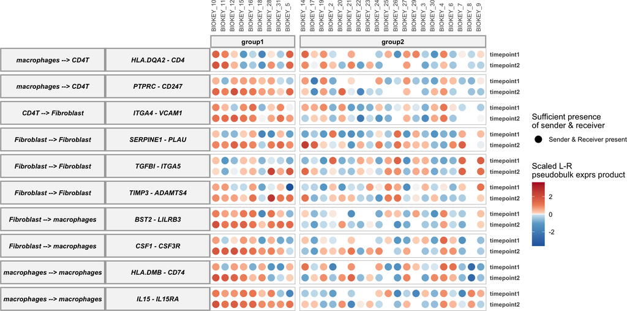

```r
keep_sender_receiver_values = c(0.25, 0.9, 1.75, 4)
names(keep_sender_receiver_values) = levels(sample_data$keep_sender_receiver)

p1 = sample_data %>% mutate(timepoint = factor(timepoint, levels = c("timepoint2","timepoint1"))) %>%
    ggplot(aes(subject, timepoint, color = scaled_LR_pb_prod, size = keep_sender_receiver)) +
    geom_point() +
    facet_grid(sender_receiver + lr_interaction ~ contrast, scales = "free", space = "free", switch = "y") +
    scale_x_discrete(position = "top") +
    theme_light() +
    theme(
      axis.ticks = element_blank(),
      axis.title = element_blank(),
      axis.text.y = element_text(size = 8, face = "bold"),
      axis.text.x = element_text(size = 8,  angle = 90,hjust = 0),
      panel.grid.major = element_blank(),
      panel.grid.minor = element_blank(),
      panel.spacing.x = unit(0.40, "lines"),
      panel.spacing.y = unit(0.25, "lines"),
      strip.text.x.top = element_text(size = 9, color = "black", face = "bold", angle = 0),
      strip.text.y.left = element_text(size = 9, color = "black", face = "bold.italic", angle = 0),
      strip.background = element_rect(color="darkgrey", fill="whitesmoke", size=1.5, linetype="solid")
    ) + labs(color = "Scaled L-R\npseudobulk exprs product", size= "Sufficient presence\nof sender & receiver") +
    scale_y_discrete(position = "right") +
    scale_size_manual(values = keep_sender_receiver_values)
  max_lfc = abs(sample_data$scaled_LR_pb_prod) %>% max()
  custom_scale_fill = scale_color_gradientn(colours = RColorBrewer::brewer.pal(n = 7, name = "RdBu") %>% rev(),values = c(0, 0.350, 0.4850, 0.5, 0.5150, 0.65, 1),  limits = c(-1*max_lfc, max_lfc))

  p1 = p1 + custom_scale_fill
p1
```